# Identifying Enron Fraud with Machine Learning

#### by Kutay Erkan

```python
# used to convert the notebook to a single python script

# !jupyter nbconvert --to script Enron_DAND6_MachineLearning.ipynb
```

## Introduction

*1. Summarize for us the goal of this project and how machine learning is useful in trying to accomplish it. As part of your answer, give some background on the dataset and how it can be used to answer the project question. Were there any outliers in the data when you got it, and how did you handle those? [relevant rubric items: “data exploration”, “outlier investigation”]*

### Summary

In this project we aim to create a Machine Learning model and a POI (Person of Interest) Identifier by using Enron email and financial data. Machine Learning is an appropriate tool for this project as it is more feasible to use finely tuned features rather than simple, deterministic rules to conclude there is a fraud; and Machine Learning is much more effective than a human when scale of the problem goes from a couple of documents to hundreds.

### Dataset

Dataset includes information from Enron employees, namely emails and financial data, which were released to public after Enron's collapse in 2001. The dataset is compiled by Udacity for the purposes of this project.

```python
# importing os and adding working directory

import os
os.chdir("..\\final_project")
```

```python
# importing necessary packages and functions

import sys
import pickle

from IPython.display import Image
import matplotlib.pyplot as plt
%matplotlib inline

# appending tools folder

sys.path.append("..\\tools\\")

from feature_format import featureFormat
from feature_format import targetFeatureSplit

# kernel option to see value of multiple statements

from IPython.core.interactiveshell import InteractiveShell
InteractiveShell.ast_node_interactivity = "all"
```

```python
# opening the dataset

data_dict = pickle.load(open("final_project_dataset.pkl", "r") )
```

Let's examine the data:

```python
print "Number of people:", len(list(data_dict))

print "Number of features:", len(data_dict.values()[0])

# counting POIs
i = 0
for person in data_dict:
    if data_dict[person]['poi'] == True:
        i+=1
print "Number of POI's:", i

print "Sample names of people (dictionary keys):\n"
print list(data_dict)[0:5], "...\n"

print "Sample attributes for the person 'METTS MARK':\n"
print data_dict['METTS MARK']
```

[output not shown]

### Outliers

As suggested in the documentation, we plot salary and bonus of the employees to see if there are any outliers.

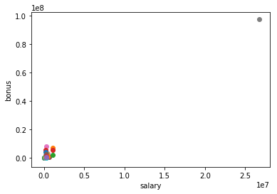

```python
# inital plot

features = ["salary", "bonus"]

data = featureFormat(data_dict, features)

for point in data:
    salary = point[0]
    bonus = point[1]
    plt.scatter( salary, bonus )

plt.xlabel("salary")
plt.ylabel("bonus")
plt.show();
```

The dot on the upper right seems to be an outlier. Upon checking the documentation we see it is a spreadsheet error, a "TOTAL" row, summing up all other values. We remove this entry.

When we check the document, we see an entry that neither follows the alphabetical order nor seems like a real person: "THE TRAVEL AGENCY IN THE PARK". It is unclear if it is an error or a correct entry, but it has no significance for our project. We remove this one too.

Finally, an entry with the key "LOCKHART, EUGENE E" does not have any values (all NaN). We remove it accordingly.

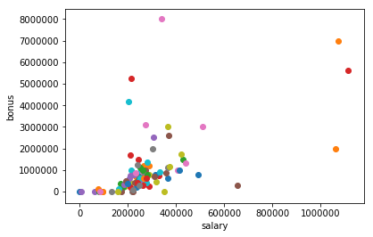

```python
# removing outliers and irrelevant data points

features = ["salary", "bonus"]
data_dict.pop('TOTAL', 0)
data_dict.pop('THE TRAVEL AGENCY IN THE PARK', 0)
data_dict.pop('LOCKHART, EUGENE E', 0)
data = featureFormat(data_dict, features)

for point in data:
    salary = point[0]
    bonus = point[1]
    plt.scatter( salary, bonus )

plt.xlabel("salary")
plt.ylabel("bonus")
plt.show();
```

```python
my_dataset = data_dict # for testing purposes

# print possible outliers

for key in data_dict:
    if data_dict[key]['salary'] != 'NaN' and data_dict[key]['bonus'] != 'NaN':
        if data_dict[key]['salary'] > 600000 or data_dict[key]['bonus'] > 5000000:
            print key
```

```
LAVORATO JOHN J
LAY KENNETH L
BELDEN TIMOTHY N
SKILLING JEFFREY K
PICKERING MARK R
FREVERT MARK A
```

Upon checking the documentation we see these are all Enron employees and relevant for our exploration, thus we keep them.

## Features (Engineering, Scaling, Selection)

*2. What features did you end up using in your POI identifier, and what selection process did you use to pick them? Did you have to do any scaling? Why or why not? As part of the assignment, you should attempt to engineer your own feature that does not come ready-made in the dataset -- explain what feature you tried to make, and the rationale behind it. (You do not necessarily have to use it in the final analysis, only engineer and test it.) In your feature selection step, if you used an algorithm like a decision tree, please also give the feature importances of the features that you use, and if you used an automated feature selection function like SelectKBest, please report the feature scores and reasons for your choice of parameter values. [relevant rubric items: “create new features”, “intelligently select features”, “properly scale features”]*

Other than financial data that we can directly use, we have also email records. We already have the number of emails sent to and received from POI's by a person, but what if that person inherently has a large number of emails?(e.g. an assistant or a secretary). Thus it is logical to engineer new features by dividing POI emails to number of all emails of that person.

- New Feature #1: fraction_from_poi (from_poi_to_this_person/to_messages)
- New Feature #2: fraction_to_poi (from_this_person_to_poi/from_messages)

```python
# defining a function to compute new features

def computeFraction( poi_messages, all_messages ):

    fraction = 0

    if poi_messages != "NaN" and all_messages != "NaN" and all_messages != 0:
        fraction = float(poi_messages) / all_messages
    else:
        return 0

    return fraction
```

Having defined the function, we compute and add new features to our dataset.

```python
# adding new features to data dictionary

for name in data_dict:

    data_point = data_dict[name]


    from_poi_to_this_person = data_point["from_poi_to_this_person"]
    to_messages = data_point["to_messages"]
    fraction_from_poi = computeFraction( from_poi_to_this_person, to_messages )
    data_point["fraction_from_poi"] = fraction_from_poi


    from_this_person_to_poi = data_point["from_this_person_to_poi"]
    from_messages = data_point["from_messages"]
    fraction_to_poi = computeFraction( from_this_person_to_poi, from_messages )
    data_point["fraction_to_poi"] = fraction_to_poi
```

Using preset functions from Udacity, we split data into features and labels. It's important "poi" is the first feature as function assumes that. "email_address" is not used as a feature as it is basically *name.surname@enron.com* and not significant.

We also split the data into training and test sets. 25% of the data is separated as test data.

```python
# splitting into features and labels

features_list = ["poi", "from_messages", "to_messages", "from_poi_to_this_person", "from_this_person_to_poi",
                 "fraction_from_poi", "fraction_to_poi", "salary", "bonus", "total_payments",
                 "deferral_payments", "expenses", "deferred_income", "long_term_incentive",
                 "restricted_stock_deferred", "shared_receipt_with_poi", "loan_advances",
                 "director_fees", "total_stock_value", "restricted_stock", "exercised_stock_options", "other"]

data_array = featureFormat( data_dict, features_list )
labels, features = targetFeatureSplit(data_array)

# creating training and test sets

from sklearn.model_selection import train_test_split

features_train, features_test, labels_train, labels_test = train_test_split(features, labels, test_size=0.25, random_state=42)
```

We scale the features as we have very different ranges across parameters. It will prove very beneficial when we try algorithms in model selection phase, if we decide to try algorithms that need scaling.

```python
# scaling the features

from sklearn.preprocessing import MinMaxScaler

min_max_scaler = MinMaxScaler()
features_train_minmax = min_max_scaler.fit_transform(features_train)
features_test_minmax = min_max_scaler.fit_transform(features_test)
```

For feature selection, we employ recursive feature selection using **RFECV** from scikit-learn. As SVC never did return with results (presumably due to missing values) a decision tree is used as a classifier.

```python
# importing modules and creating RFECV

# from sklearn.svm import SVC
from sklearn import tree
# from sklearn.model_selection import StratifiedKFold
from sklearn.feature_selection import RFECV

# svc = SVC(kernel='linear')
clf_dt = tree.DecisionTreeClassifier(random_state=0)

# rfecv = RFECV(estimator=svc, step=1, cv=StratifiedKFold(labels_train), scoring='accuracy')
rfecv = RFECV(estimator=clf_dt, step=1, cv=None, scoring='accuracy')

temp = rfecv.fit(features_train, labels_train)
```

```
Optimal number of features : 13
[9 8 6 1 5 1 4 3 2 1 1 1 1 1 1 1 1 1 7 1 1]
Use these features: ['from_this_person_to_poi', 'fraction_to_poi', 'deferral_payments', 'expenses', 'deferred_income', 'long_term_incentive', 'restricted_stock_deferred', 'shared_receipt_with_poi', 'loan_advances', 'director_fees', 'total_stock_value', 'exercised_stock_options', 'other']
```

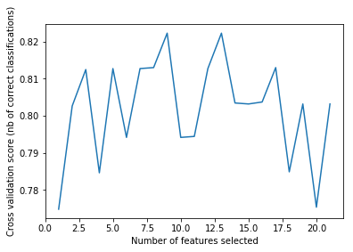

```python
# print features

print("Optimal number of features : %d" % rfecv.n_features_)
print rfecv.ranking_

i=0
index_list=[]
for i in range(len(rfecv.ranking_)):
    if rfecv.ranking_[i]==1:
        index_list.append(features_list[i+1])
print "Use these features:", index_list

# plot number of features VS. cross-validation scores

plt.figure()
plt.xlabel("Number of features selected")
plt.ylabel("Cross validation score (nb of correct classifications)")
plt.plot(range(1, len(rfecv.grid_scores_) + 1), rfecv.grid_scores_)
plt.show();
```

RFECV suggests 13 features, and we feed POI + these features to our models by creating a new features_list.

```python
# splitting into features and labels, using new features_list

features_list = ['poi', 'from_this_person_to_poi', 'fraction_to_poi', 'deferral_payments',
                 'expenses', 'deferred_income', 'long_term_incentive', 'restricted_stock_deferred',
                 'shared_receipt_with_poi', 'loan_advances', 'director_fees', 'total_stock_value',
                 'exercised_stock_options', 'other']

data_array = featureFormat( data_dict, features_list )
labels, features = targetFeatureSplit(data_array)

# creating training and test sets

from sklearn.model_selection import train_test_split

features_train, features_test, labels_train, labels_test = train_test_split(features, labels, test_size=0.3, random_state=42)
```

```python
# scaling the features, using new_features_list

from sklearn.preprocessing import MinMaxScaler

min_max_scaler = MinMaxScaler()
features_train_minmax = min_max_scaler.fit_transform(features_train)
features_test_minmax = min_max_scaler.fit_transform(features_test)
```

## Algorithms

*3. What algorithm did you end up using? What other one(s) did you try? How did model performance differ between algorithms? [relevant rubric item: “pick an algorithm”]*

Following algorithms have been tried: Decision Tree, Gaussian NB, and logistic regression.

```python
# importing sklearn modules

from sklearn import tree # already imported before, but is here too for readability
from sklearn.naive_bayes import GaussianNB
from sklearn import linear_model


# importing sklearn metrics

from sklearn.metrics import accuracy_score
from sklearn.metrics import precision_score
from sklearn.metrics import recall_score
from sklearn.metrics import f1_score


# defining a scores function to evaluate algorithms

def scores(name, labels, predictions):
    accuracy = round(accuracy_score(labels, predictions), 2)
    precision = round(precision_score(labels, predictions), 2)
    recall = round(recall_score(labels, predictions), 2)
    f1 = round(f1_score(labels, predictions), 2)

    print name
    print "Accuracy:", accuracy
    print "Recall:", recall
    print "Precision:", precision
    print "F1 Score:", f1
```

```python
import warnings
warnings.filterwarnings('ignore')

# defining different algorithms

clf_tree = tree.DecisionTreeClassifier(random_state=0)
clf_NB = GaussianNB()
reg = linear_model.LogisticRegression()

# fitting algorithms with a variable assigned to stop unwanted output

temp1 = clf_tree.fit(features_train_minmax, labels_train)
temp2 = clf_NB.fit(features_train_minmax, labels_train)
temp3 = reg.fit(features_train_minmax, labels_train)

# predicting and printing results

pred_clf_tree = clf_tree.predict(features_test_minmax)
pred_clf_NB = clf_NB.predict(features_test_minmax)
pred_reg = reg.predict(features_test_minmax)

print "Test set size:", len(labels_test)
print " "
scores("Decision Tree", labels_test, pred_clf_tree)
print " "
scores("GaussianNB", labels_test, pred_clf_NB)
print " "
scores("Logistic Regression", labels_test, pred_reg)
```

```
Test set size: 43

Decision Tree
Accuracy: 0.81
Recall: 0.43
Precision: 0.43
F1 Score: 0.43

GaussianNB
Accuracy: 0.84
Recall: 0.0
Precision: 0.0
F1 Score: 0.0

Logistic Regression
Accuracy: 0.84
Recall: 0.0
Precision: 0.0
F1 Score: 0.0
```

By our test data, performance of all 3 algorithms seem horrendous. But this is because class imbalance problem, and we should test our algorithms using tester.py as it uses stratified shuffle split and represents the true performance better. Results of the untuned algorithms are as follows:

- **DecisionTreeClassifier**

  ```
       (class_weight=None, criterion='gini', max_depth=None,
        max_features=None, max_leaf_nodes=None,
        min_impurity_split=1e-07, min_samples_leaf=1,
        min_samples_split=2, min_weight_fraction_leaf=0.0,
        presort=False, random_state=None, splitter='best')
  ```

- **Accuracy**: 0.82587 **Precision**: 0.35059 **Recall**: 0.35900 **F1**: 0.35474 **F2**: 0.35729
- Total predictions: 15000 True positives: 718 False positives: 1330 False negatives: 1282 True negatives: 11670
- **GaussianNB**

  ```
        (priors=None)
  ```

- **Accuracy**: 0.46087 **Precision**: 0.17529 **Recall**: 0.82150 **F1**: 0.28893 **F2**: 0.47286
- Total predictions: 15000 True positives: 1643 False positives: 7730 False negatives: 357 True negatives: 5270
- **LogisticRegression**

  ```
        (C=1.0, class_weight=None, dual=False, fit_intercept=True,
        intercept_scaling=1, max_iter=100, multi_class='ovr', n_jobs=1,
        penalty='l2', random_state=None, solver='liblinear', tol=0.0001,
        verbose=0, warm_start=False)
  ```

- **Accuracy**: 0.80480 **Precision**: 0.22014 **Recall**: 0.18250 **F1**: 0.19956 **F2**: 0.18896
- Total predictions: 15000 True positives: 365 False positives: 1293 False negatives: 1635 True negatives: 11707

Our models are not great, but at least they are much more respectable when tested with a "fair" method.

## Tuning

*4. What does it mean to tune the parameters of an algorithm, and what can happen if you don’t do this well? How did you tune the parameters of your particular algorithm? What parameters did you tune? (Some algorithms do not have parameters that you need to tune -- if this is the case for the one you picked, identify and briefly explain how you would have done it for the model that was not your final choice or a different model that does utilize parameter tuning, e.g. a decision tree classifier). [relevant rubric items: “discuss parameter tuning”, “tune the algorithm”]*

Tuning means changing and updating parameters so that our algorithms work in the most suitable and optimal way for our context. Most of the parameters use a default and we might not have to change it, but in some cases it is necessary to change the parameter. Reason behind this could be getting most correct results, such as shuffling the data in the feature selection. We might also want to change minimum split in a decision tree so that we can decrease model fitting from minutes to seconds. Or we might simply set a random state in nondeterministic algorithms, so that our results become reproducible by someone else.

Following parameter tuning has been done to algorithms(scores are computed using tester.py):

- For the **Decision Tree**, changing criterion from "gini" to "entropy" increased *precision* to 0.41348, *recall* to 0.41100 and *F1 score* to 0.41224. Increasing minimum saple leaf from default 1 to 4 increased *precision* to 0.48469, decreased *recall* to 0.38000 and increased *F1 score* to 0.42601.
- For the **Gaussian Naive Bayes**, changing priors to [0.95, 0.05] increased *precision* to 0.20686, decreased *recall* to 0.75050 and increased *F1 score* to 0.32433.
- For **Logistic Regression**, different "C" values for regularization has been tried using **GridSearchCV** but default value 1.0 produced optimal results. "liblinear" solver also hasn't been changed due to our small dataset.

```python
# defining different algorithms

clf_tree = tree.DecisionTreeClassifier(criterion= "entropy", min_samples_leaf=4, random_state=0)
clf_NB = GaussianNB(priors=[0.95, 0.05])
reg = linear_model.LogisticRegression()

# param_grid = {'C': [0.001, 0.01, 0.1, 1, 10, 100, 1000] }
# reg = GridSearchCV(reg, param_grid)

# fitting algorithms with a variable assigned to stop unwanted output

temp1 = clf_tree.fit(features_train_minmax, labels_train)
temp2 = clf_NB.fit(features_train_minmax, labels_train)
temp3 = reg.fit(features_train_minmax, labels_train)

# predicting and printing results

pred_clf_tree = clf_tree.predict(features_test_minmax)
pred_clf_NB = clf_NB.predict(features_test_minmax)
pred_reg = reg.predict(features_test_minmax)

print "Test set size:", len(labels_test)
print " "
scores("Decision Tree", labels_test, pred_clf_tree)
print " "
scores("GaussianNB", labels_test, pred_clf_NB)
print " "
scores("Logistic Regression", labels_test, pred_reg)
```

```
Test set size: 43

Decision Tree
Accuracy: 0.72
Recall: 0.14
Precision: 0.14
F1 Score: 0.14

GaussianNB
Accuracy: 0.84
Recall: 0.0
Precision: 0.0
F1 Score: 0.0

Logistic Regression
Accuracy: 0.84
Recall: 0.0
Precision: 0.0
F1 Score: 0.0
```

## Validation

*5. What is validation, and what’s a classic mistake you can make if you do it wrong? How did you validate your analysis? [relevant rubric items: “discuss validation”, “validation strategy”]*

Validation, in general terms, testing your model with the data you haven't "touched". If a big enough training set hasn't been created, or the created test set has been used in model creation (I did this mistake in this project before correcting it) **overfitting** can happen. Another problem that undermines validation is wrong assumptions. For example if we assume our features are independent but they are highly correlated, it could damage model results (possibly) and model credibility (definitely).

## Evaluation

*6. Give at least 2 evaluation metrics and your average performance for each of them. Explain an interpretation of your metrics that says something human-understandable about your algorithm’s performance. [relevant rubric item: “usage of evaluation metrics”]*

Main evaluation metrics used in Machine Learning is as follows:

- **Accuracy**: Fraction of predictions (by the model) that are correct.
- **Recall**: Fraction of all true positive observations that are predicted correctly by the model.
- **Precision**: Fraction of positive predictions that are correct.
- **F1 Score**: Harmonic mean of Recall and Precision.

### Final Model Performance:

#### DecisionTreeClassifier

```
        (class_weight=None, criterion='entropy', max_depth=None,
        max_features=None, max_leaf_nodes=None,
        min_impurity_split=1e-07, min_samples_leaf=4,
        min_samples_split=2, min_weight_fraction_leaf=0.0,
        presort=False, random_state=0, splitter='best')
```

**Performance**

- Accuracy: 0.86347
- Precision: 0.48469
- Recall: 0.38000
- F1: 0.42601
- F2: 0.39716

**Predictions**

- Total predictions: 15000
- True positives: 760
- False positives: 808
- False negatives: 1240
- True negatives: 12192

## References

- https://www.udacity.com/
- https://docs.google.com/document/d/1NDgi1PrNJP7WTbfSUuRUnz8yzs5nGVTSzpO7oeNTEWA/pub?embedded=true
- http://scikit-learn.org/
- https://docs.python.org/3.3/library/functions.html#zip
- https://www.tutorialspoint.com/python/dictionary_get.htm
- http://book.pythontips.com/en/latest/map_filter.html
- https://stackoverflow.com/questions/1810743/how-to-set-the-current-working-directory-in-python
- https://stackoverflow.com/questions/13462365/python-2-7-counting-number-of-dictionary-items-with-given-value
- https://stackoverflow.com/questions/25050311/extract-first-item-of-each-sublist-in-python
- https://stackoverflow.com/questions/9535954/printing-lists-as-tabular-data
- http://scikit-learn.org/stable/modules/generated/sklearn.feature_selection.RFECV.html